# Pricing Calibration Diagnostics

Calibration and Revenue Analysis

Author

Mikus

Published

July 5, 2026

## 1. Purpose

This report investigates the pricing behavior observed in the simulation results. It summarizes the calibration checks, fleet size sensitivity, pricing sensitivity, revenue decomposition, and spatial diagnostics used to explain the pricing outcomes discussed in the thesis.

## Fleet Size Robustness

This section evaluates how fleet size affects operational performance and revenue in the Interaction scenario. Fleet sizes between 40 and 100 vehicles were evaluated using 50 simulation runs per configuration.

```r
df_fleet <- read_csv("../Data/PricingDiagnostics/revenue_decomposition_fleet_size.csv")

# Format columns for display
table_fleet <- df_fleet %>%
  transmute(
    `Fleet Size (N)` = as.integer(fleet_size),
    `Service Rate` = sprintf("%.2f%%", service_rate * 100),
    `Overload Freq.` = sprintf("%.2f%%", overload_frequency * 100),
    `Completed Trips` = round(completed_trips, 1),
    `Total Revenue` = sprintf("$%.2f", total_revenue),
    `Revenue / Vehicle` = sprintf("$%.2f", revenue_per_vehicle),
    `Average Price` = sprintf("$%.2f", average_price),
    `Avg. Idle Vehicles` = round(average_idle_vehicles, 2),
    `Idle Share` = sprintf("%.2f%%", idle_share * 100)
  )

print_table(table_fleet, "Table 1: Fleet Size Sensitivity Decomposition (Interaction Scenario)")
```

Table 1: Fleet Size Sensitivity Decomposition (Interaction Scenario)

| Fleet Size (N) | Service Rate | Overload Freq. | Completed Trips | Total Revenue | Revenue / Vehicle | Average Price | Avg. Idle Vehicles | Idle Share |
| --- | --- | --- | --- | --- | --- | --- | --- | --- |
| 40 | 70.55% | 44.61% | 6611.9 | $49467.33 | $1236.68 | $10.71 | 4.65 | 11.64% |
| 50 | 76.31% | 29.23% | 7792.7 | $37327.69 | $746.55 | $6.90 | 8.53 | 17.06% |
| 60 | 78.93% | 23.14% | 8299.9 | $31718.30 | $528.64 | $5.46 | 16.16 | 26.93% |
| 80 | 79.38% | 22.54% | 8380.9 | $30806.95 | $385.09 | $5.27 | 35.93 | 44.91% |
| 100 | 79.49% | 22.17% | 8419.8 | $30155.21 | $301.55 | $5.13 | 55.76 | 55.76% |

### Visualizations

#### Total Revenue vs. Fleet Size

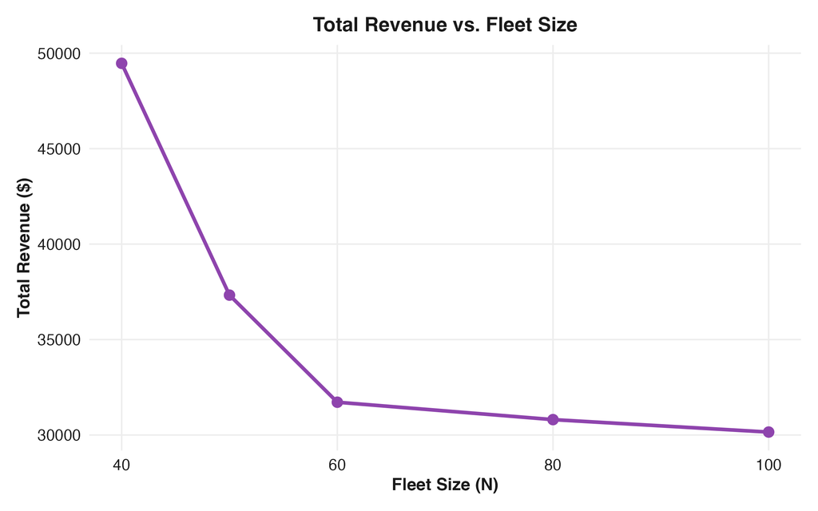

#### Revenue per Vehicle vs. Fleet Size

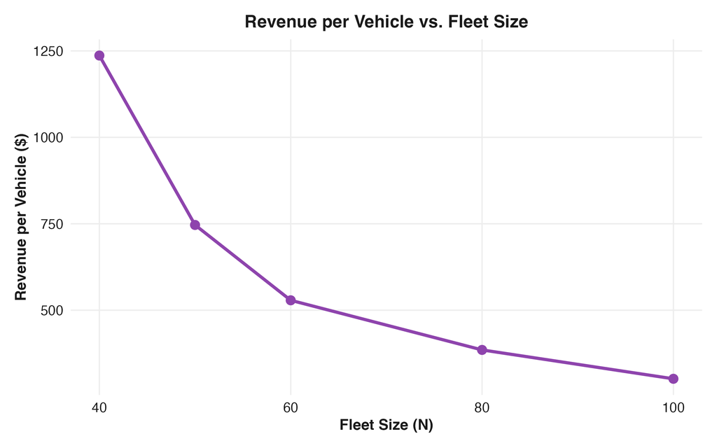

#### Average Idle Vehicles vs. Fleet Size

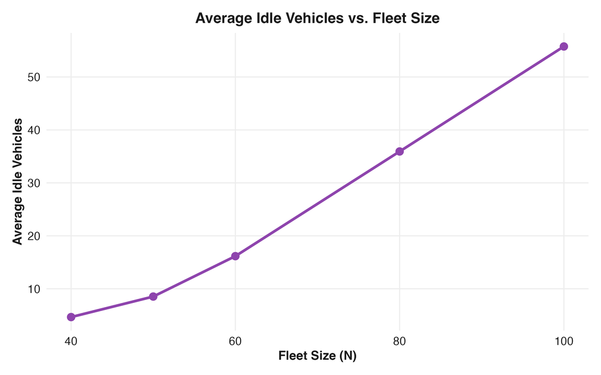

#### Service Rate vs. Fleet Size

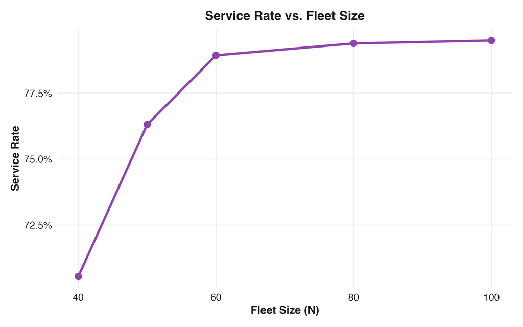

## 3. Pricing Sensitivity Robustness

```r
df_alpha <- read_csv("../Data/PricingDiagnostics/calibration_alpha_robustness.csv")

table_alpha <- df_alpha %>%
  transmute(
    Alpha = alpha,
    `Service Rate` = sprintf("%.2f%%", service_rate * 100),
    `Overload Freq.` = sprintf("%.2f%%", overload_frequency * 100),
    `Revenue / Vehicle` = sprintf("$%.2f", revenue_per_vehicle),
    `Price Volatility` = sprintf("%.3f", price_volatility),
    `Average Price` = sprintf("$%.2f", average_price),
    `Completed Trips` = round(completed_trips, 1)
  )

print_table(table_alpha, "Table 2: Pricing Sensitivity (Alpha) Robustness (Interaction, N=80)")
```

| Alpha | Service Rate | Overload Freq. | Revenue / Vehicle | Price Volatility | Average Price | Completed Trips |
| --- | --- | --- | --- | --- | --- | --- |
| 0.1 | 77.86% | 25.35% | $480.64 | 1.391 | $4.76 | 8341.8 |
| 0.2 | 78.62% | 23.57% | $500.30 | 1.288 | $5.06 | 8325.9 |
| 0.3 | 78.93% | 23.14% | $528.64 | 1.433 | $5.46 | 8299.9 |
| 0.4 | 79.10% | 22.40% | $554.93 | 1.585 | $5.88 | 8210.1 |

### Visualizations

#### Revenue per Vehicle vs. Pricing Sensitivity (Alpha)

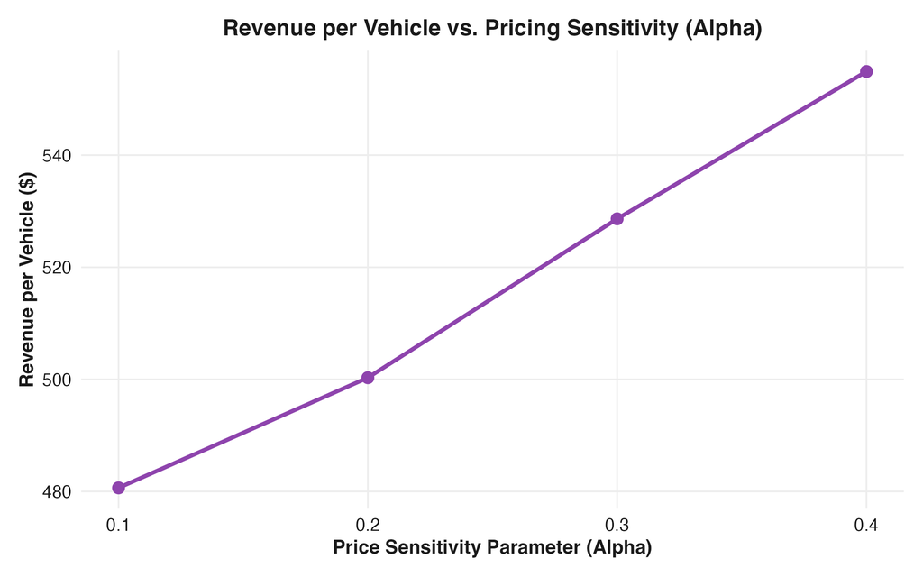

#### Average Price vs. Pricing Sensitivity (Alpha)

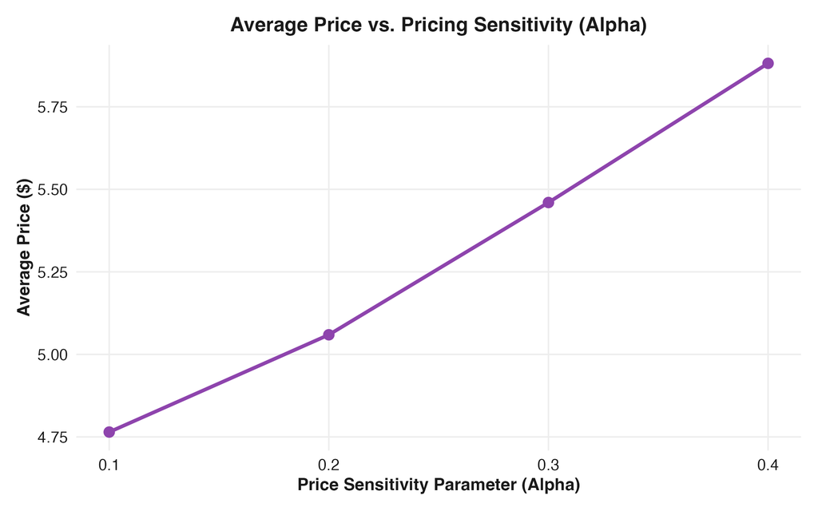

#### Price Volatility vs. Pricing Sensitivity (Alpha)

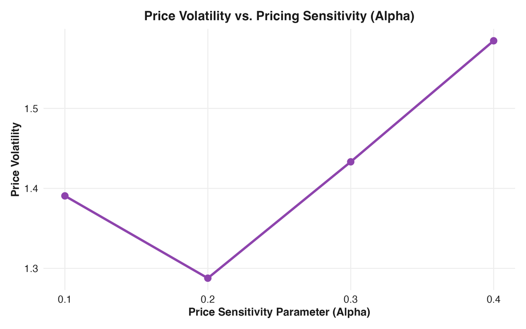

## 4. Revenue Decomposition across Main Scenarios

This section compares the main simulation scenarios to separate the effects of completed trips, average prices, and total revenue.

```r
df_scenarios <- read_csv("../Data/PricingDiagnostics/revenue_decomposition_main_scenarios.csv")

# Map to clean capitalized labels
df_scenarios <- df_scenarios %>%
  mutate(
    scenario_label = case_when(
      scenario == "passive" ~ "Passive",
      scenario == "pricing_only" ~ "Pricing Only",
      scenario == "rebalancing_only" ~ "Rebalancing Only",
      scenario == "interaction" ~ "Interaction",
      scenario == "governance" ~ "Governance",
      TRUE ~ scenario
    )
  )

table_scenarios <- df_scenarios %>%
  transmute(
    Scenario = scenario_label,
    `Service Rate` = sprintf("%.2f%%", service_rate * 100),
    `Overload Freq.` = sprintf("%.2f%%", overload_frequency * 100),
    `Completed Trips` = round(completed_trips, 1),
    `Total Revenue` = sprintf("$%.2f", total_revenue),
    `Revenue / Vehicle` = sprintf("$%.2f", revenue_per_vehicle),
    `Rev / Completed Trip` = sprintf("$%.2f", revenue_per_completed_trip),
    `Average Price` = sprintf("$%.2f", average_price),
    `Avg. Idle Vehicles` = round(average_idle_vehicles, 2),
    `Idle Share` = sprintf("%.2f%%", idle_share * 100),
    `Mismatch (Imbalance)` = sprintf("%.3f", demand_supply_mismatch)
  )

print_table(table_scenarios, "Table 3: Scenario Performance & Revenue Decomposition (N=80 Baseline)")
```

Table 3: Scenario Performance & Revenue Decomposition (N=80 Baseline)

| Scenario | Service Rate | Overload Freq. | Completed Trips | Total Revenue | Revenue / Vehicle | Rev / Completed Trip | Average Price | Avg. Idle Vehicles | Idle Share | Mismatch (Imbalance) |
| --- | --- | --- | --- | --- | --- | --- | --- | --- | --- | --- |
| Passive | 60.28% | 65.43% | 4490.8 | $81487.68 | $1018.60 | $18.15 | $17.17 | 59.14 | 73.92% | 0.136 |
| Pricing Only | 70.58% | 45.47% | 6987.3 | $38195.51 | $477.44 | $5.47 | $9.30 | 47.45 | 59.31% | 0.111 |
| Rebalancing Only | 74.52% | 35.58% | 5080.5 | $90529.92 | $1131.62 | $17.82 | $17.17 | 53.82 | 67.27% | 0.123 |
| Interaction | 79.38% | 22.54% | 8380.9 | $30806.95 | $385.09 | $3.68 | $5.27 | 35.93 | 44.91% | 0.089 |
| Governance | 75.65% | 31.81% | 7509.3 | $39411.36 | $492.64 | $5.25 | $8.06 | 42.33 | 52.91% | 0.101 |

### Visualizations

Trade-off between volume and unit fare:

#### Completed Trips vs. Revenue per Completed Trip by Scenario

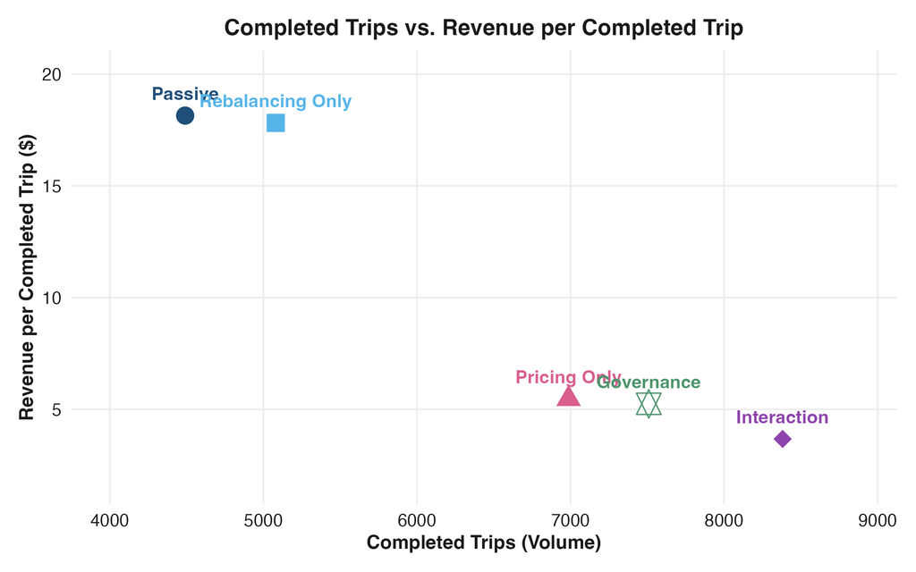

## 5. Capacity-Regime Scenario Comparison

Scenario performance is compared across different fleet sizes (N = 40, 60, and 80) to evaluate how physical capacity influences pricing and operational performance.

```r
df_scarcity <- read_csv("../Data/PricingDiagnostics/capacity_regime_scenario_comparison.csv")

# Extract matching scenarios for N=80 from df_scenarios
df_scenarios_80 <- df_scenarios %>%
  filter(scenario %in% c("passive", "pricing_only", "rebalancing_only", "interaction")) %>%
  mutate(fleet_size = 80) %>%
  select(colnames(df_scarcity))

df_comparison <- bind_rows(df_scarcity, df_scenarios_80) %>%
  arrange(fleet_size, scenario) %>%
  mutate(
    scenario_label = case_when(
      scenario == "passive" ~ "Passive",
      scenario == "pricing_only" ~ "Pricing Only",
      scenario == "rebalancing_only" ~ "Rebalancing Only",
      scenario == "interaction" ~ "Interaction",
      TRUE ~ scenario
    )
  )

table_comparison <- df_comparison %>%
  transmute(
    Scenario = scenario_label,
    `Fleet Size (N)` = as.integer(fleet_size),
    `Service Rate` = sprintf("%.2f%%", service_rate * 100),
    `Completed Trips` = round(completed_trips, 1),
    `Total Revenue` = sprintf("$%.2f", total_revenue),
    `Revenue / Vehicle` = sprintf("$%.2f", revenue_per_vehicle),
    `Average Price` = sprintf("$%.2f", average_price),
    `Avg. Idle Vehicles` = round(average_idle_vehicles, 2),
    `Idle Share` = sprintf("%.2f%%", idle_share * 100)
  )

print_table(table_comparison, "Table 4: Scenario Performance Across Capacity Regimes (N=40, N=60, N=80)")
```

Table 4: Scenario Performance Across Capacity Regimes (N=40, N=60, N=80)

| Scenario | Fleet Size (N) | Service Rate | Completed Trips | Total Revenue | Revenue / Vehicle | Average Price | Avg. Idle Vehicles | Idle Share |
| --- | --- | --- | --- | --- | --- | --- | --- | --- |
| Interaction | 40 | 70.55% | 6611.9 | $49467.33 | $1236.68 | $10.71 | 4.65 | 11.64% |
| Passive | 40 | 54.41% | 4199.2 | $76348.08 | $1908.70 | $17.17 | 20.48 | 51.19% |
| Pricing Only | 40 | 66.40% | 6356.3 | $44485.82 | $1112.15 | $10.83 | 10.35 | 25.87% |
| Rebalancing Only | 40 | 70.89% | 4923.5 | $87557.98 | $2188.95 | $17.17 | 13.83 | 34.58% |
| Interaction | 60 | 78.93% | 8299.9 | $31718.30 | $528.64 | $5.46 | 16.16 | 26.93% |
| Passive | 60 | 57.90% | 4370.1 | $79425.84 | $1323.76 | $17.17 | 39.66 | 66.10% |
| Pricing Only | 60 | 70.80% | 6949.2 | $38456.35 | $640.94 | $9.34 | 27.60 | 46.00% |
| Rebalancing Only | 60 | 73.60% | 5023.3 | $89537.16 | $1492.29 | $17.17 | 33.96 | 56.60% |
| Interaction | 80 | 79.38% | 8380.9 | $30806.95 | $385.09 | $5.27 | 35.93 | 44.91% |
| Passive | 80 | 60.28% | 4490.8 | $81487.68 | $1018.60 | $17.17 | 59.14 | 73.92% |
| Pricing Only | 80 | 70.58% | 6987.3 | $38195.51 | $477.44 | $9.30 | 47.45 | 59.31% |
| Rebalancing Only | 80 | 74.52% | 5080.5 | $90529.92 | $1131.62 | $17.17 | 53.82 | 67.27% |

### Visualizations

Total Revenue across scenarios and capacity levels.

#### Total Revenue by Scenario and Fleet Size

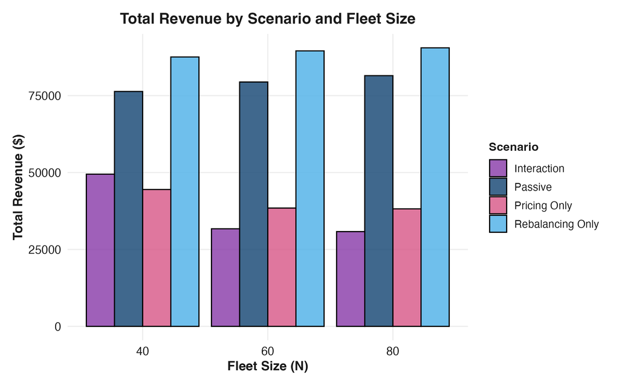

## 6. Spatial Flow Diagnostic

This section summarizes the spatial distribution of vehicles in the baseline Interaction scenario ($N = 80$). The following tables show vehicle allocation, idle vehicles, and serving and rebalancing flows across all zones.

### Table 5: Spatial Distribution & Operational Metrics

| Zone | Avg. Assigned Vehicles | Avg. Idle Vehicles | Avg. Total Arrivals | Avg. Total Departures | Avg. Effective Demand | Avg. Completed Trips |
| --- | --- | --- | --- | --- | --- | --- |
| **R1** | 4.1365 | 0.5484 | 2.0360 | 2.0630 | 2.6325 | 1.5218 |
| **R2** | 4.2922 | 0.6364 | 2.0648 | 2.0920 | 2.7144 | 1.5266 |
| **R3** | 4.3850 | 0.6882 | 2.0868 | 2.1115 | 2.7841 | 1.5281 |
| **R4** | 4.4903 | 0.7707 | 2.0939 | 2.1187 | 2.8387 | 1.5304 |
| **C** | 46.4782 | 29.0348 | 7.4781 | 7.4441 | 5.9827 | 7.4773 |
| **A** | 16.2180 | 4.2523 | 3.5063 | 3.5251 | 4.1610 | 3.0982 |

### Table 6: Decomposed Inflows and Outflows (Serving vs. Rebalancing)

| Zone | Serving Arrivals | Rebalancing Arrivals | Serving Departures | Rebalancing Departures |
| --- | --- | --- | --- | --- |
| **R1** | 1.5218 | 0.5143 | 1.7181 | 0.3448 |
| **R2** | 1.5266 | 0.5382 | 1.7897 | 0.3023 |
| **R3** | 1.5281 | 0.5587 | 1.8519 | 0.2596 |
| **R4** | 1.5304 | 0.5636 | 1.8954 | 0.2233 |
| **C** | 7.4773 | 0.0008 | 5.9818 | 1.4623 |
| **A** | 3.0982 | 0.4080 | 3.5248 | 0.0002 |

### Interpretation

The Center zone contains approximately 29 idle vehicles on average (about 81% of the total idle fleet), indicating substantial vehicle accumulation. Because the destination probability matrix continuously directs vehicles to the Center, local oversupply develops and prices remain close to the minimum price. This explains the low average platform price observed in the Interaction scenario.

## 7. Pricing Mechanism Diagnostic

This section summarizes the price distribution and regional price differences for the baseline Interaction scenario ($N = 80$).

### Price Distribution

- **Mean Price:** $4.65
- **Median Price:** $4.40
- **Standard Deviation:** $3.48
- **Minimum Price:** $1.00
- **Maximum Price:** $21.40
- **25th Percentile:** $1.00
- **75th Percentile:** $6.72

**Price Distribution**

- Below $5: **56.37%**
- Below $10: **92.10%**
- Below the baseline zone price: **99.10%**
- Above the baseline zone price: **0.90%**

### Table 7. Average Price by Zone

| Zone | Baseline Price | Average Price |
| --- | --- | --- |
| **R1** | 15.00 | 5.11 |
| **R2** | 15.00 | 7.40 |
| **R3** | 15.00 | 6.80 |
| **R4** | 15.00 | 5.40 |
| **C** | 18.00 | 1.14 |
| **A** | 25.00 | 2.02 |

### Table 8. Average Pricing and Operational Gaps

| Zone | Avg. Pricing Imbalance Gap | Avg. Operational Mismatch Gap |
| --- | --- | --- |
| **R1** | 2.116 | 2.748 |
| **R2** | 2.068 | 2.770 |
| **R3** | 1.984 | 2.736 |
| **R4** | 2.044 | 2.890 |
| **C** | -20.884 | 6.074 |
| **A** | -1.074 | 4.092 |

## 8. Interpretation

### 1. Dynamic Pricing and Revenue

Dynamic pricing improves coordination and increases the number of completed trips, but reduces total revenue in the baseline configuration ($N=80$). The higher trip volume is not sufficient to compensate for the much lower average fare.

### 3. Center Zone Oversupply

The spatial diagnostics show that the Center acts as a vehicle sink because many trips end there. The resulting oversupply pushes prices close to the $1.00 price floor, explaining the low average platform price.

### 4. Implications

These findings suggest that the observed pricing behavior is mainly driven by the chosen fleet size and spatial demand structure rather than by the pricing parameter itself. The diagnostics therefore help explain the revenue patterns observed in the main thesis results.

## 9. Generated Outputs

The report produces an HTML version of this document together with the figures and summary CSV files used in the pricing diagnostics. outputs are saved in `outputs/calibration_robustness/`